# Arijus Jaloveckas

# 1. Bibliotekos

```r
library(tidyverse)
library(rstatix)
library(readxl)
library(ggpubr)
library(patchwork)
library(RColorBrewer)
library(dplyr)
```

# 2. Duomenų įsikėlimas, pirminis susipažinimas su duomenimis, priskiriamas tinkamas R duomenų tipas kintamiesiems, nenaudojamų stulpelių išmetimas.

```r
library(readr)
alzaimeris <- read_csv("Plasma lipidomics in Alzheimers disease and its progression-1.csv")
```

```r
summary(alzaimeris)
```

```
     Sample        Diagnostic            Sex                 Age
 Min.   :  1.00   Length:212         Length:212         Min.   :52.00
 1st Qu.: 53.75   Class :character   Class :character   1st Qu.:70.00
 Median :106.50   Mode  :character   Mode  :character   Median :74.00
 Mean   :106.50                                         Mean   :73.49
 3rd Qu.:159.25                                         3rd Qu.:78.00
 Max.   :212.00                                         Max.   :85.00

      MMSE       CSF Amyloid (pg/mL) CSF Total tau (pg/mL)
 Min.   :15.00   Min.   : 243.0      Min.   :  67.1
 1st Qu.:23.00   1st Qu.: 420.5      1st Qu.: 254.8
 Median :25.00   Median : 551.0      Median : 408.5
 Mean   :25.06   Mean   : 642.9      Mean   : 464.3
 3rd Qu.:27.00   3rd Qu.: 711.8      3rd Qu.: 613.8
 Max.   :30.00   Max.   :3863.0      Max.   :1550.0
                 NA's   :14          NA's   :14
 CSF Phosphorylated tau (pg/mL)    APOE4
 Min.   : 15.60                 Length:212
 1st Qu.: 48.02                 Class :character
 Median : 68.00                 Mode  :character
 Mean   : 79.84
 3rd Qu.: 92.00
 Max.   :512.00
 NA's   :14
 Progression to Alzheimer's Disease Progression time (months)
 Length:212                         Min.   : 7.00
 Class :character                   1st Qu.:12.00
 Mode  :character                   Median :16.00
                                    Mean   :19.94
                                    3rd Qu.:23.50
                                    Max.   :55.00
                                    NA's   :165
```

```r
glimpse(alzaimeris)
```

```
Rows: 212
Columns: 11
$ Sample                               <dbl> 1, 2, 3, 4, 5, 6, 7, 8, 9, 10, 11…
$ Diagnostic                           <chr> "Alzheimer's Disease", "Alzheimer…
$ Sex                                  <chr> "Female", "Female", "Female", "Ma…
$ Age                                  <dbl> 68, 66, 72, 73, 75, 83, 76, 67, 8…
$ MMSE                                 <dbl> 26, 22, 23, 25, 15, 27, 22, 25, 2…
$ `CSF Amyloid (pg/mL)`                <dbl> 688, 489, 509, 544, 303, 520, 243…
$ `CSF Total tau (pg/mL)`              <dbl> 369, 482, 329, 482, 806, 501, 686…
$ `CSF Phosphorylated tau (pg/mL)`     <dbl> 107, 176, 114, 80, 120, 67, 94, N…
$ APOE4                                <chr> "Yes", "Yes", "Yes", "No", "No", …
$ `Progression to Alzheimer's Disease` <chr> NA, NA, NA, NA, NA, NA, NA, NA, N…
$ `Progression time (months)`          <dbl> NA, NA, NA, NA, NA, NA, NA, NA, N…
```

```r
alzaimeris <- alzaimeris |>
  select(
    1:8
  ) |>
  mutate(
    Diagnostic = factor(Diagnostic),
    Sex = factor(Sex)
  ) |>
  rename(
    Amyloid = `CSF Amyloid (pg/mL)`,
    Total_tau = `CSF Total tau (pg/mL)`,
    P_tau = `CSF Phosphorylated tau (pg/mL)`
  ) |>
  drop_na()
```

Pašalinu du paskutinius stulpelius nes jie nebus reikalingi analizėje. Taip pat pašalinti tiriamieji su nežinomom reikšmėm, kadangi tokie tiriamieji turėjo tik MMSE rezultatų informaciją.

# 3. Aprašomoji statistika, kintamųjų pasiskirstymas pagal grupes, išskirčių šalinimas.

Šiais duomenimis siekiu išsiaiškinti, kokie MMSE rezultatų ir įvairių biožymenų koncentracijos cerebrospinaliniame skystyje skirtumai tarp žmonių su skirtingomis protinės būklės diagnozėmis. Iškėliau hipotezes:

Nulinė hipotezė (H)₀: Nėra reikšmingo skirtumo tarp skirtingų biožymeklių koncentracijos ir MMSE balų skirtingose grupėse.

Alternatyvioji hipotezė (H₁): Tarp skirtingų biožymeklių koncentracijos ir MMSE balų skirtingose grupėse yra reikšmingas skirtumas.

Ištirti skirtingos lyties ir amžiaus žmonių protinė būklė (MMSE testas) ir biožymenys:

Alzheimer’s Disease - žmonės sergantys alzaimeriu (tikimąsi 10-19 MMSE ir mažiausios amiloidų koncentracijos)

Mild Cognitive Impairment - lengvą protinį sutrikimą turintys žmonės (tikimąsi 20-23 MMSE, didesnės už “Alzheimer’s Disease” amiloidų koncentracijos CSF)

MMSE - protinės būklės rezultatai (10-19 Alzaimeris, 20-23 lengvas protinis sutrikimas, 24-30 žmogus sveikas)

Amyloid - amiloidinių darinių koncentracija cerebrospinaliniame skystyje (pg/mL) (tikimąsi mažesnės koncentracijos pažeistos protinės būklės grupėse)

Total_tau - bendra tau baltymo koncentracija cerebrospinaliniame skystyje (pg/mL) (tikimąsi didesnės pažeistos protinės būklės grupėse)

P_tau - fosforilinto tau baltymo koncentracija cerebrospinaliniame skystyje (pg/mL) (tikimąsi didesnės pažeistos protinės būklės grupėse)

## Centrinės ir sklaidos charakteristikos:

### MMSE

```r
alzaimeris |>
  group_by(Diagnostic) |>
  get_summary_stats(
  MMSE,
  show = c( "mean", "sd", "median", "iqr")
)
```

```
# A tibble: 3 × 7
  Diagnostic                variable     n  mean    sd median   iqr
  <fct>                     <fct>    <dbl> <dbl> <dbl>  <dbl> <dbl>
1 Alzheimer's Disease       MMSE        91  23.4  2.41   23       3
2 Control                   MMSE        20  28.4  2.48   29.5     2
3 Mild Cognitive Impairment MMSE        87  26.2  2.66   27       3
```

### Amyloid

```r
alzaimeris |>
  group_by(Diagnostic) |>
  get_summary_stats(
  Amyloid,
  show = c( "mean", "sd", "median", "iqr")
)
```

```
# A tibble: 3 × 7
  Diagnostic                variable     n  mean    sd median   iqr
  <fct>                     <fct>    <dbl> <dbl> <dbl>  <dbl> <dbl>
1 Alzheimer's Disease       Amyloid     91  508.  202.   493   184
2 Control                   Amyloid     20 1112.  748.  1016.  667
3 Mild Cognitive Impairment Amyloid     87  676.  308.   604   430.
```

### Total_tau

```r
alzaimeris |>
  group_by(Diagnostic) |>
  get_summary_stats(
  Total_tau,
  show = c( "mean", "sd", "median", "iqr")
  )
```

```
# A tibble: 3 × 7
  Diagnostic                variable      n  mean    sd median   iqr
  <fct>                     <fct>     <dbl> <dbl> <dbl>  <dbl> <dbl>
1 Alzheimer's Disease       Total_tau    91  551.  273.    494  337
2 Control                   Total_tau    20  291.  217.    248  179.
3 Mild Cognitive Impairment Total_tau    87  413.  256.    332  311
```

### P_tau

```r
alzaimeris |>
  group_by(Diagnostic) |>
  get_summary_stats(
  P_tau,
  show = c( "mean", "sd", "median", "iqr")
  )
```

```
# A tibble: 3 × 7
  Diagnostic                variable     n  mean    sd median   iqr
  <fct>                     <fct>    <dbl> <dbl> <dbl>  <dbl> <dbl>
1 Alzheimer's Disease       P_tau       91  87.8  54.1   81    42.1
2 Control                   P_tau       20  56.3  46.0   45.0  31.9
3 Mild Cognitive Impairment P_tau       87  76.9  66.5   63.5  43.3
```

### Išvada: visose tirtose koncentracijose yra didelis standartinis nuokrypis, tikėtina, kad duomenys bus pasiskirstę neparametriškai ir kad bus išskirčių.

```r
MMSE_box <- ggplot(alzaimeris, aes(Diagnostic, MMSE, fill = Diagnostic)) +
  geom_boxplot() +
  theme(axis.text.x = element_text(angle = 45))

A_box <- ggplot(alzaimeris, aes(Diagnostic, Amyloid, fill = Diagnostic)) +
  geom_boxplot() +
  theme(axis.text.x = element_text(angle = 45))

tau_box <- ggplot(alzaimeris, aes(Diagnostic, Total_tau, fill = Diagnostic)) +
  geom_boxplot() +
  theme(axis.text.x = element_text(angle = 45))

Ptau_box <- ggplot(alzaimeris, aes(Diagnostic, P_tau, fill = Diagnostic)) +
  geom_boxplot() +
  theme(axis.text.x = element_text(angle = 45))

MMSE_density <- ggplot(alzaimeris, aes(MMSE, fill = Diagnostic)) +
  geom_density(alpha = 0.4)

A_density <- ggplot(alzaimeris, aes(Amyloid, fill = Diagnostic)) +
  geom_density(alpha = 0.4)

tau_density <- ggplot(alzaimeris, aes(Total_tau, fill = Diagnostic)) +
  geom_density(alpha = 0.4)

Ptau_density <- ggplot(alzaimeris, aes(P_tau, fill = Diagnostic)) +
  geom_density(alpha = 0.4)
```

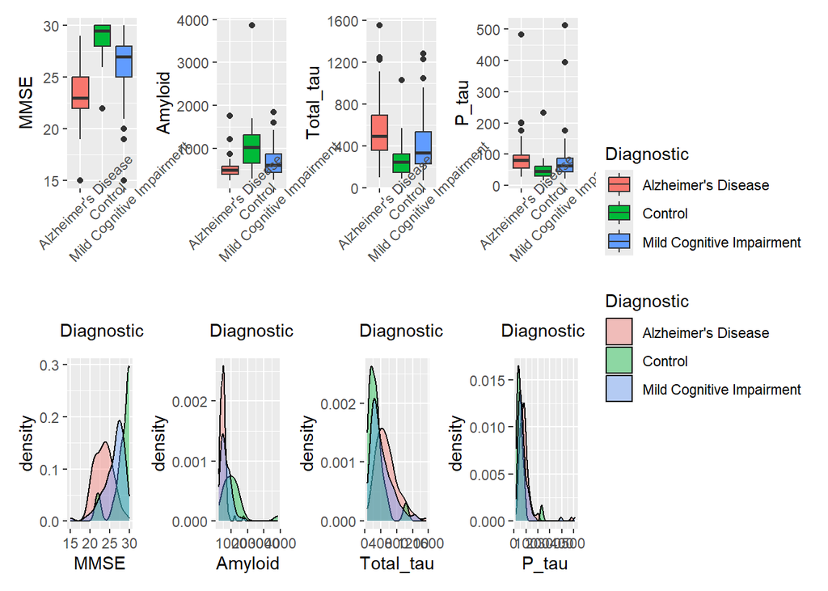

```r
netransformuotas <- ((MMSE_box | A_box | tau_box | Ptau_box) /
(MMSE_density | A_density | tau_density | Ptau_density)) +
  plot_layout(guides = 'collect')

netransformuotas
```

Išvada: matoma daug išskirčių visose grupėse, visuose matavimuose. Taip pat matoma, kad MMSE skirstinys yra pasislinkęs į dešinę, o likę CSF rodikliai pasiskirstę į kairę.

## Išskirtys

### MMSE

```r
alzaimeris |>
  group_by(Diagnostic) |>
  identify_outliers(MMSE)
```

```
# A tibble: 6 × 10
  Diagnostic         Sample Sex     Age  MMSE Amyloid Total_tau P_tau is.outlier
  <fct>               <dbl> <fct> <dbl> <dbl>   <dbl>     <dbl> <dbl> <lgl>
1 Alzheimer's Disea…      5 Fema…    75    15     303       806 120   TRUE
2 Control               205 Fema…    73    22    1032       163  30.1 TRUE
3 Control               212 Male     69    22     291       288  45.2 TRUE
4 Mild Cognitive Im…    148 Fema…    76    19    1135       316  63.9 TRUE
5 Mild Cognitive Im…    150 Fema…    70    15     422       675 115   TRUE
6 Mild Cognitive Im…    174 Male     70    20     662       247  44.7 TRUE
# ℹ 1 more variable: is.extreme <lgl>
```

Išvada: pastebėta 1 ekstremali išskirtis: nr. 150.

### Amyloid

```r
alzaimeris |>
  group_by(Diagnostic) |>
  identify_outliers(Amyloid)
```

```
# A tibble: 6 × 10
  Diagnostic         Sample Sex     Age  MMSE Amyloid Total_tau P_tau is.outlier
  <fct>               <dbl> <fct> <dbl> <dbl>   <dbl>     <dbl> <dbl> <lgl>
1 Alzheimer's Disea…     36 Fema…    83    21    1758       439  71   TRUE
2 Alzheimer's Disea…     60 Male     65    21    1213       371  65   TRUE
3 Alzheimer's Disea…     91 Fema…    76    21     864       331  53   TRUE
4 Control               193 Fema…    69    29    3863      1030 232   TRUE
5 Mild Cognitive Im…    105 Male     70    27    1845       353  92.4 TRUE
6 Mild Cognitive Im…    110 Male     64    27    1592       215  56.1 TRUE
# ℹ 1 more variable: is.extreme <lgl>
```

### Total_tau

```r
alzaimeris |>
  group_by(Diagnostic) |>
  identify_outliers(Total_tau)
```

```
# A tibble: 7 × 10
  Diagnostic         Sample Sex     Age  MMSE Amyloid Total_tau P_tau is.outlier
  <fct>               <dbl> <fct> <dbl> <dbl>   <dbl>     <dbl> <dbl> <lgl>
1 Alzheimer's Disea…     16 Fema…    82    22     429      1550   158 TRUE
2 Alzheimer's Disea…     52 Male     81    23     479      1225   199 TRUE
3 Alzheimer's Disea…     96 Male     78    20     566      1246   146 TRUE
4 Control               193 Fema…    69    29    3863      1030   232 TRUE
5 Mild Cognitive Im…    108 Male     78    27     784      1231   394 TRUE
6 Mild Cognitive Im…    112 Fema…    59    26     435      1047   127 TRUE
7 Mild Cognitive Im…    131 Fema…    71    25     627      1284   150 TRUE
# ℹ 1 more variable: is.extreme <lgl>
```

Išvada: yra 1 ekstremali išskirtis: nr. 193.

### P_tau

```r
alzaimeris |>
  group_by(Diagnostic) |>
  identify_outliers(P_tau)
```

```
# A tibble: 8 × 10
  Diagnostic         Sample Sex     Age  MMSE Amyloid Total_tau P_tau is.outlier
  <fct>               <dbl> <fct> <dbl> <dbl>   <dbl>     <dbl> <dbl> <lgl>
1 Alzheimer's Disea…      2 Fema…    66    22     489       482   176 TRUE
2 Alzheimer's Disea…     26 Fema…    72    24     464       474   202 TRUE
3 Alzheimer's Disea…     52 Male     81    23     479      1225   199 TRUE
4 Alzheimer's Disea…     81 Male     74    29     344      1042   483 TRUE
5 Control               193 Fema…    69    29    3863      1030   232 TRUE
6 Mild Cognitive Im…    106 Fema…    73    29     928       531   176 TRUE
7 Mild Cognitive Im…    108 Male     78    27     784      1231   394 TRUE
8 Mild Cognitive Im…    141 Fema…    78    24     390       259   512 TRUE
# ℹ 1 more variable: is.extreme <lgl>
```

## Duomenų transformacijos pagal identifikuotas problemas

Pašalinamos ekstremalios išskirtys:

```r
ids_to_remove <- c(150, 36, 60, 141, 108, 81, 193)

alzaimeris_transformed <- alzaimeris[!(alzaimeris$Sample %in% ids_to_remove), ]
```

Log transformuojamos MMSE, CSF amyloid, CSF total tau ir CSF phosphorylated tau reikšmės:

```r
alzaimeris_transformed <- alzaimeris_transformed |>
  mutate(
    log_MMSE = log(MMSE),
    log_amyloid = log(Amyloid),
    log_tau = log(Total_tau),
    log_Ptau = log(P_tau)
)
```

## Pertvarkytų duomenų aprašomoji statistika ir grafinis atvaizdavimas

### MMSE

```r
alzaimeris_transformed |>
  group_by(Diagnostic) |>
  get_summary_stats(
  log_MMSE,
  show = c( "mean", "sd", "median", "iqr")
)
```

```
# A tibble: 3 × 7
  Diagnostic                variable     n  mean    sd median   iqr
  <fct>                     <fct>    <dbl> <dbl> <dbl>  <dbl> <dbl>
1 Alzheimer's Disease       log_MMSE    88  3.15 0.104   3.16 0.128
2 Control                   log_MMSE    19  3.34 0.097   3.40 0.069
3 Mild Cognitive Impairment log_MMSE    84  3.27 0.096   3.30 0.113
```

### Amyloid

```r
alzaimeris_transformed |>
  group_by(Diagnostic) |>
  get_summary_stats(
  log_amyloid,
  show = c( "mean", "sd", "median", "iqr")
)
```

```
# A tibble: 3 × 7
  Diagnostic                variable        n  mean    sd median   iqr
  <fct>                     <fct>       <dbl> <dbl> <dbl>  <dbl> <dbl>
1 Alzheimer's Disease       log_amyloid    88  6.15 0.286   6.20 0.366
2 Control                   log_amyloid    19  6.78 0.457   6.91 0.685
3 Mild Cognitive Impairment log_amyloid    84  6.43 0.437   6.42 0.682
```

### Total_tau

```r
alzaimeris_transformed |>
  group_by(Diagnostic) |>
  get_summary_stats(
  log_tau,
  show = c( "mean", "sd", "median", "iqr")
  )
```

```
# A tibble: 3 × 7
  Diagnostic                variable     n  mean    sd median   iqr
  <fct>                     <fct>    <dbl> <dbl> <dbl>  <dbl> <dbl>
1 Alzheimer's Disease       log_tau     88  6.18 0.515   6.20 0.677
2 Control                   log_tau     19  5.40 0.543   5.51 0.798
3 Mild Cognitive Impairment log_tau     84  5.83 0.582   5.80 0.87
```

### P_tau

```r
alzaimeris_transformed |>
  group_by(Diagnostic) |>
  get_summary_stats(
  log_Ptau,
  show = c( "mean", "sd", "median", "iqr")
  )
```

```
# A tibble: 3 × 7
  Diagnostic                variable     n  mean    sd median   iqr
  <fct>                     <fct>    <dbl> <dbl> <dbl>  <dbl> <dbl>
1 Alzheimer's Disease       log_Ptau    88  4.35 0.41    4.39 0.577
2 Control                   log_Ptau    19  3.76 0.456   3.80 0.687
3 Mild Cognitive Impairment log_Ptau    84  4.11 0.442   4.14 0.683
```

## Grafinis duomenų pasiskirstymo atvaizdavimas

```r
MMSE_box_t <- ggplot(alzaimeris_transformed, aes(Diagnostic, log_MMSE, fill = Diagnostic)) +
  geom_boxplot() +
  theme(axis.text.x = element_text(angle = 45))

A_box_t <- ggplot(alzaimeris_transformed, aes(Diagnostic, log_amyloid, fill = Diagnostic)) +
  geom_boxplot() +
  theme(axis.text.x = element_text(angle = 45))

tau_box_t <- ggplot(alzaimeris_transformed, aes(Diagnostic, log_tau, fill = Diagnostic)) +
  geom_boxplot() +
  theme(axis.text.x = element_text(angle = 45))

Ptau_box_t <- ggplot(alzaimeris_transformed, aes(Diagnostic, log_Ptau, fill = Diagnostic)) +
  geom_boxplot() +
  theme(axis.text.x = element_text(angle = 45))

MMSE_density_t <- ggplot(alzaimeris_transformed, aes(log_MMSE, fill = Diagnostic)) +
  geom_density(alpha = 0.4)

A_density_t <- ggplot(alzaimeris_transformed, aes(log_amyloid, fill = Diagnostic)) +
  geom_density(alpha = 0.4)

tau_density_t <- ggplot(alzaimeris_transformed, aes(log_tau, fill = Diagnostic)) +
  geom_density(alpha = 0.4)

Ptau_density_t <- ggplot(alzaimeris_transformed, aes(log_Ptau, fill = Diagnostic)) +
  geom_density(alpha = 0.4)
```

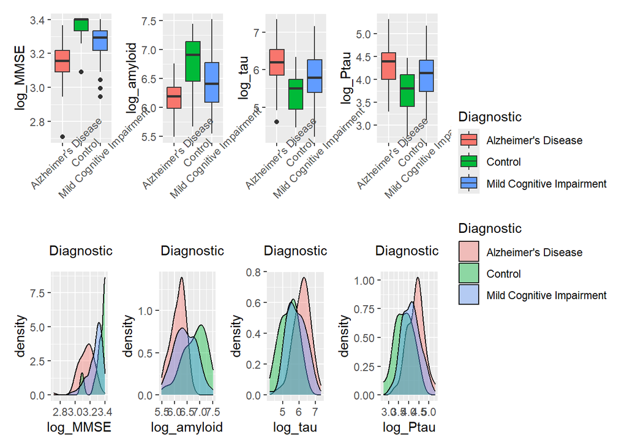

```r
transformuotas <- ((MMSE_box_t | A_box_t | tau_box_t | Ptau_box_t) /
(MMSE_density_t | A_density_t | tau_density_t | Ptau_density_t)) +
  plot_layout(guides = 'collect')

transformuotas
```

Išvada: log transformacija ir ekstremalių reikšmių pašalinimas padėjo pasiekti didesnį normalumą kintamiesiems. MMSE kintamojo kontrolės grupė išlieka pasislinkusi į dešinę, todėl galimai reikės naudoti neparametrinį metodą MMSE kintamajam.

# 4. Palyginamoji statistika

Siekiant įvertinti amiloidų, totalaus tau ir fosforilinto tau koncentracijos skirtumus tarp trijų žmonių grupių, naudosiu vienfaktorę (one-way) ANOVA analizę. MMSE naudosiu neparametrinę Kruskal-Wallis analizę

Vienfaktorinė ANOVA turi keletą prielaidų:

Išskirtys (jau patikrinta, duomenys turėjo ekstremalių išskirčių, tačiau jos pašalintos). Normalumo prielaida. (jei netenkinama, naudojamas Kruskal-Wallis) Dispersijos homogeniškumo prielaida. (jei netenkinama, naudojama Welch ANOVA)

## Normalumo prielaida

### MMSE

```r
alzaimeris_transformed |>
  group_by(Diagnostic) |>
  shapiro_test(log_MMSE)
```

```
# A tibble: 3 × 4
  Diagnostic                variable statistic          p
  <fct>                     <chr>        <dbl>      <dbl>
1 Alzheimer's Disease       log_MMSE     0.946 0.00104
2 Control                   log_MMSE     0.674 0.0000277
3 Mild Cognitive Impairment log_MMSE     0.880 0.00000114
```

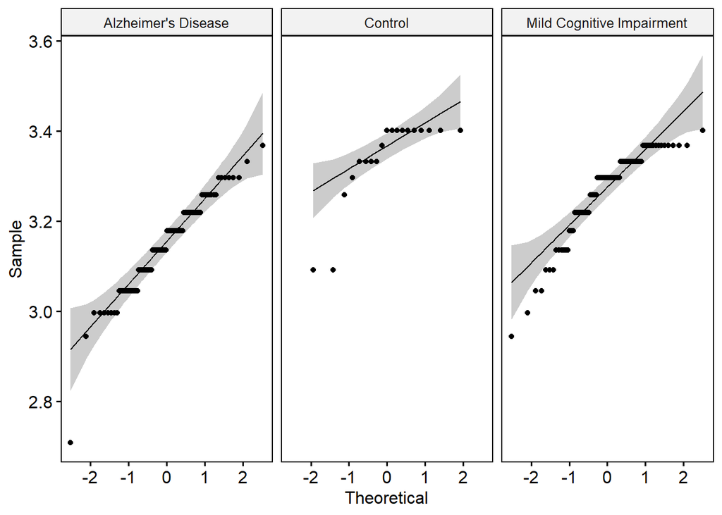

```r
ggqqplot(alzaimeris_transformed, "log_MMSE", facet.by = "Diagnostic")
```

Pažeista normalumo prielaida. Reikės naudoti neparametrinį analizės metodą.

### Amyloid

```r
alzaimeris_transformed |>
  group_by(Diagnostic) |>
  shapiro_test(log_amyloid)
```

```
# A tibble: 3 × 4
  Diagnostic                variable    statistic      p
  <fct>                     <chr>           <dbl>  <dbl>
1 Alzheimer's Disease       log_amyloid     0.976 0.0983
2 Control                   log_amyloid     0.946 0.337
3 Mild Cognitive Impairment log_amyloid     0.988 0.621
```

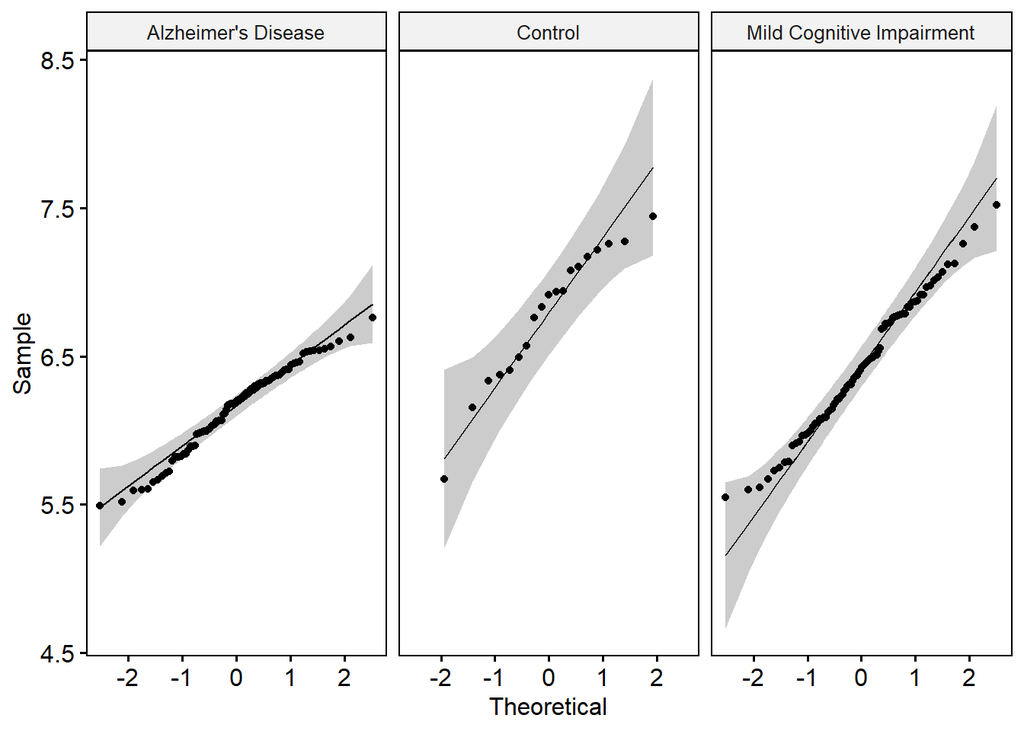

```r
ggqqplot(alzaimeris_transformed, "log_amyloid", facet.by = "Diagnostic")
```

Normalumo prielaida nepažeista.

### Total_tau

```r
alzaimeris_transformed |>
  group_by(Diagnostic) |>
  shapiro_test(log_tau)
```

```
# A tibble: 3 × 4
  Diagnostic                variable statistic     p
  <fct>                     <chr>        <dbl> <dbl>
1 Alzheimer's Disease       log_tau      0.989 0.637
2 Control                   log_tau      0.969 0.748
3 Mild Cognitive Impairment log_tau      0.987 0.550
```

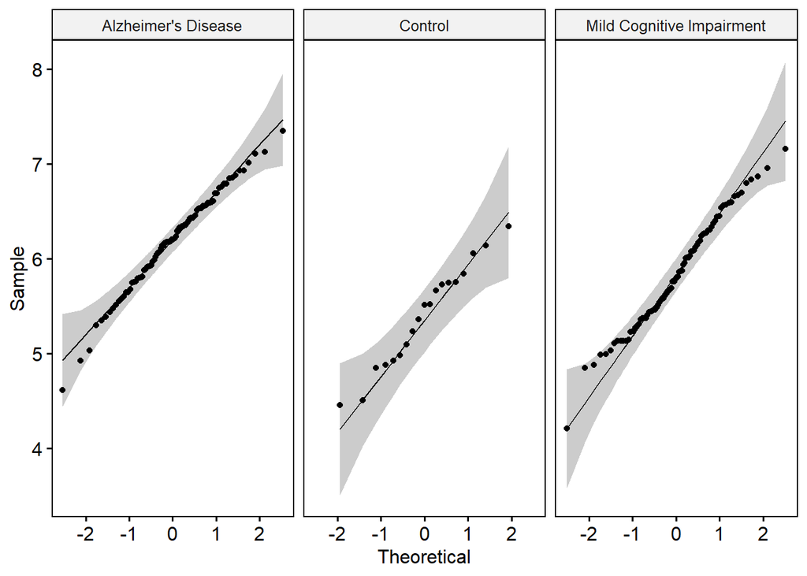

```r
ggqqplot(alzaimeris_transformed, "log_tau", facet.by = "Diagnostic")
```

Normalumo prielaida nepažeista.

### P_tau

```r
alzaimeris_transformed |>
  group_by(Diagnostic) |>
  shapiro_test(log_Ptau)
```

```
# A tibble: 3 × 4
  Diagnostic                variable statistic     p
  <fct>                     <chr>        <dbl> <dbl>
1 Alzheimer's Disease       log_Ptau     0.988 0.636
2 Control                   log_Ptau     0.966 0.690
3 Mild Cognitive Impairment log_Ptau     0.989 0.704
```

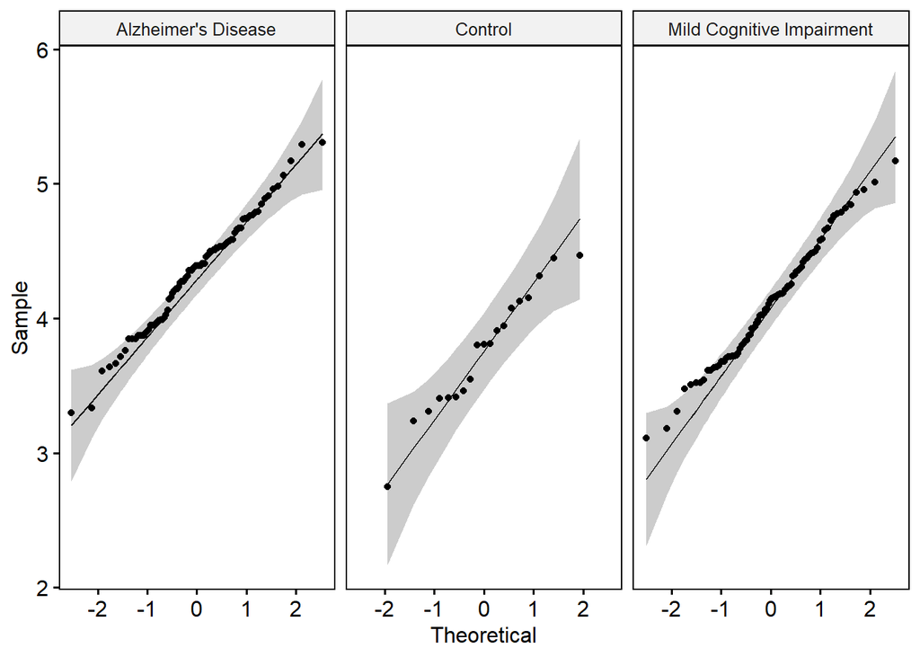

```r
ggqqplot(alzaimeris_transformed, "log_Ptau", facet.by = "Diagnostic")
```

Normalumo prielaida nepažeista.

## Dispersijos homogeniškumo prielaida

### Amyloid

```r
alzaimeris_transformed |>
  levene_test(log_amyloid ~ Diagnostic)
```

```
# A tibble: 1 × 4
    df1   df2 statistic        p
  <int> <int>     <dbl>    <dbl>
1     2   188      7.93 0.000493
```

Homogeniškumo prielaida pažeista.

### Total_tau

```r
alzaimeris_transformed |>
  levene_test(log_tau ~ Diagnostic)
```

```
# A tibble: 1 × 4
    df1   df2 statistic     p
  <int> <int>     <dbl> <dbl>
1     2   188      1.30 0.275
```

Homogeniškumo prielaida tenkinama.

### P_tau

```r
alzaimeris_transformed |>
  levene_test(log_Ptau ~ Diagnostic)
```

```
# A tibble: 1 × 4
    df1   df2 statistic     p
  <int> <int>     <dbl> <dbl>
1     2   188     0.564 0.570
```

Homogeniškumo prielaida tenkinama.

# Hipotezių tikrinimas

### MMSE

Naudojamas Kruskal-Wallis testas, kadangi MMSE kintamajame grupės nėra normaliai pasiskirsčiusios, taip pat kontrolinė grupė yra žymiai mažesnė už kitas dvi grupes.

```r
result_MMSE <- alzaimeris_transformed |> kruskal_test(log_MMSE ~ Diagnostic)
result_MMSE
```

```
# A tibble: 1 × 6
  .y.          n statistic    df        p method
* <chr>    <int>     <dbl> <int>    <dbl> <chr>
1 log_MMSE   191      70.4     2 5.19e-16 Kruskal-Wallis
```

Skirtumai tarp grupių statistiškai reikšmingi, toliau atliekama efekto dydžio ir post-hoc analizės (post-hoc analizei naudojamas Dunn testas, nes jisai naudojamas kartu su Kruskal-Wallis analize):

```r
alzaimeris_transformed |>  kruskal_effsize(log_MMSE ~ Diagnostic)
```

```
# A tibble: 1 × 5
  .y.          n effsize method  magnitude
* <chr>    <int>   <dbl> <chr>   <ord>
1 log_MMSE   191   0.364 eta2[H] large
```

```r
pwc_MMSE <- alzaimeris_transformed |>
  dunn_test(log_MMSE ~ Diagnostic)
pwc_MMSE
```

```
# A tibble: 3 × 9
  .y.      group1    group2    n1    n2 statistic        p    p.adj p.adj.signif
* <chr>    <chr>     <chr>  <int> <int>     <dbl>    <dbl>    <dbl> <chr>
1 log_MMSE Alzheime… Contr…    88    19      6.73 1.66e-11 3.96e-11 ****
2 log_MMSE Alzheime… Mild …    88    84      6.77 1.32e-11 3.96e-11 ****
3 log_MMSE Control   Mild …    19    84     -2.64 8.24e- 3 8.24e- 3 **
```

Skirtumai tarp visų grupių yra statistiškai reikšmingi, efekto dydis yra didelis.

### Rezultatų vaizdavimas su tarpgrupiniais skirtumais:

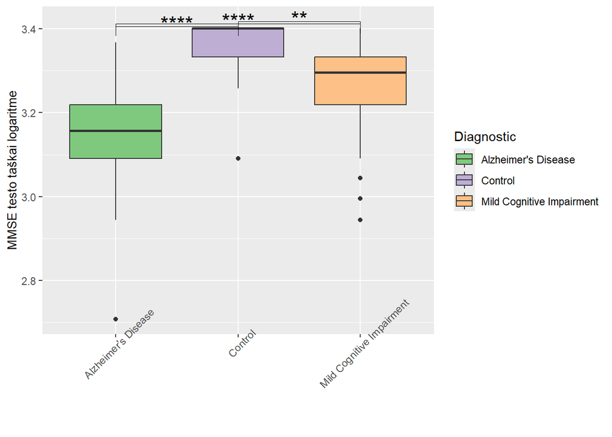

```r
pwc_MMSE <- pwc_MMSE |>  add_xy_position(x = "Diagnostic")

final_MMSE <- ggplot(alzaimeris_transformed, aes(Diagnostic, log_MMSE)) +
  geom_boxplot(aes(fill = Diagnostic)) +
  stat_pvalue_manual(pwc_MMSE, hide.ns = TRUE, size = 6) +
  scale_fill_brewer(palette = "Accent")  +
  labs(y = "MMSE testo taškai logaritme") +
  theme(axis.title.x = element_blank(),
     axis.title.y = element_text(size = 10),
    axis.text.x = element_text(angle = 45)
    )

final_MMSE
```

## Amyloid

Naudosiu Welch-ANOVA, kadangi buvo nepažeista normalumo prielaida, bet pažeista homogeniškumo.

```r
result_amyloid <- alzaimeris_transformed |>  welch_anova_test(log_amyloid ~ Diagnostic)
result_amyloid
```

```
# A tibble: 1 × 7
  .y.             n statistic   DFn   DFd            p method
* <chr>       <int>     <dbl> <dbl> <dbl>        <dbl> <chr>
1 log_amyloid   191      24.7     2  46.7 0.0000000472 Welch ANOVA
```

Skirtumai tarp grupių statistiškai reikšmingi, toliau atliekama tarpgrupinė analizė (naudojamas games_howell testas nes jis naudojamas su Welch ANOVA):

```r
pwc_amyloid <- alzaimeris_transformed |> games_howell_test(log_amyloid ~ Diagnostic)
pwc_amyloid
```

```
# A tibble: 3 × 8
  .y.         group1     group2 estimate conf.low conf.high   p.adj p.adj.signif
* <chr>       <chr>      <chr>     <dbl>    <dbl>     <dbl>   <dbl> <chr>
1 log_amyloid Alzheimer… Contr…    0.634    0.359    0.909  2.61e-5 ****
2 log_amyloid Alzheimer… Mild …    0.277    0.143    0.411  8.14e-6 ****
3 log_amyloid Control    Mild …   -0.357   -0.643   -0.0707 1.2 e-2 *
```

Skirtumai tarp visų grupių statistiškai reikšmingi

### Rezultatų vaizdavimas su tarpgrupiniais skirtumais:

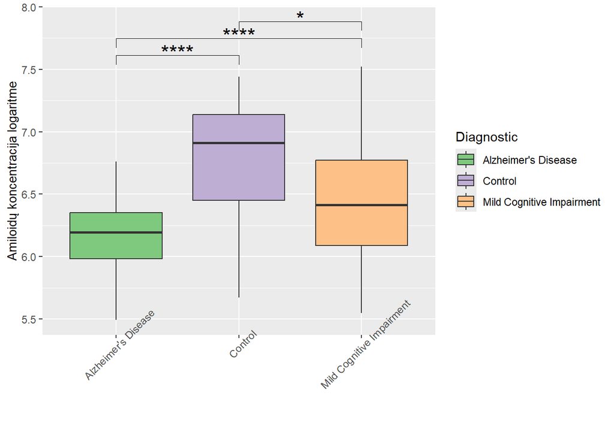

```r
pwc_amyloid <- pwc_amyloid |>  add_xy_position(x = "Diagnostic")

final_amyloid <- ggplot(alzaimeris_transformed, aes(Diagnostic, log_amyloid)) +
  geom_boxplot(aes(fill = Diagnostic)) +
  stat_pvalue_manual(pwc_amyloid, hide.ns = TRUE, size = 6) +
  scale_fill_brewer(palette = "Accent")  +
  labs(y = "Amiloidų koncentracija logaritme") +
  theme(axis.title.x = element_blank(),
     axis.title.y = element_text(size = 10),
    axis.text.x = element_text(angle = 45)
    )

final_amyloid
```

## Total_tau

Bus naudojama one-way ANOVA, kadangi tenkinama tiek normalumo, tiek homogeniškumo prielaida. One-way Anova, o ne two-way ANOVA bus naudojama todėl, nes yra tik vienas kintamasis pagal kurį norima palyginti grupes.

```r
result_tau <- alzaimeris_transformed |>  anova_test(log_tau ~ Diagnostic)
result_tau
```

```
ANOVA Table (type II tests)

      Effect DFn DFd      F        p p<.05   ges
1 Diagnostic   2 188 19.716 1.69e-08     * 0.173
```

Skirtumai tarp grupių statistiškai reikšmingi, toliau atliekamas tarpgrupinis palyginimas (naudojamas tukey, nes jisai naudojamas su ANOVA)

```r
pwc_tau <- alzaimeris_transformed|> tukey_hsd(log_tau ~ Diagnostic)
pwc_tau
```

```
# A tibble: 3 × 9
  term       group1        group2 null.value estimate conf.low conf.high   p.adj
* <chr>      <chr>         <chr>       <dbl>    <dbl>    <dbl>     <dbl>   <dbl>
1 Diagnostic Alzheimer's … Contr…          0   -0.788   -1.12     -0.460 1.53e-7
2 Diagnostic Alzheimer's … Mild …          0   -0.354   -0.552    -0.157 1.06e-4
3 Diagnostic Control       Mild …          0    0.433    0.104     0.763 6.07e-3
# ℹ 1 more variable: p.adj.signif <chr>
```

Tarp visų grupių yra statistiškai reikšmingas skirtumas.

### Rezultatų vaizdavimas su tarpgrupiniais skirtumais:

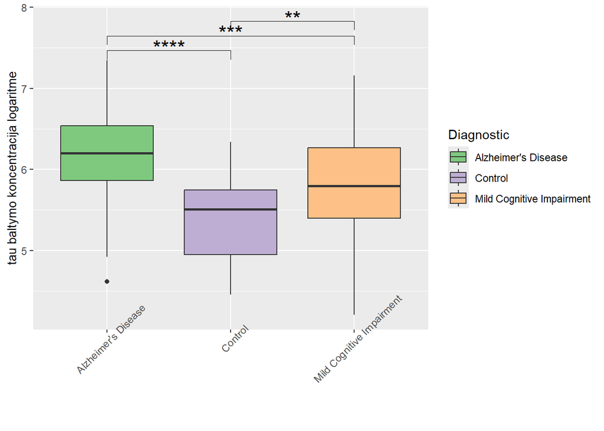

```r
pwc_tau <- pwc_tau |>  add_xy_position(x = "Diagnostic")

final_tau <- ggplot(alzaimeris_transformed, aes(Diagnostic, log_tau)) +
  geom_boxplot(aes(fill = Diagnostic)) +
  stat_pvalue_manual(pwc_tau, hide.ns = TRUE, size = 6) +
  scale_fill_brewer(palette = "Accent")  +
  labs(y = "tau baltymo koncentracija logaritme") +
  theme(axis.title.x = element_blank(),
     axis.title.y = element_text(size = 10),
    axis.text.x = element_text(angle = 45)
    )

final_tau
```

## P_tau

Bus naudojama one-way ANOVA, kadangi tenkinama tiek normalumo, tiek homogeniškumo prielaida. One-way Anova, o ne two-way ANOVA bus naudojama todėl, nes yra tik vienas kintamasis pagal kurį norima palyginti grupes.

```r
result_Ptau <- alzaimeris_transformed |>  anova_test(log_Ptau ~ Diagnostic)
result_Ptau
```

```
ANOVA Table (type II tests)

      Effect DFn DFd      F        p p<.05   ges
1 Diagnostic   2 188 16.812 1.92e-07     * 0.152
```

Skirtumai tarp grupių statistiškai reikšmingi, toliau atliekamas tarpgrupinis palyginimas (naudojamas tukey, nes jisai naudojamas su ANOVA)

```r
pwc_Ptau <- alzaimeris_transformed|> tukey_hsd(log_Ptau ~ Diagnostic)
pwc_Ptau
```

```
# A tibble: 3 × 9
  term       group1        group2 null.value estimate conf.low conf.high   p.adj
* <chr>      <chr>         <chr>       <dbl>    <dbl>    <dbl>     <dbl>   <dbl>
1 Diagnostic Alzheimer's … Contr…          0   -0.589  -0.845    -0.333  5.19e-7
2 Diagnostic Alzheimer's … Mild …          0   -0.232  -0.387    -0.0774 1.43e-3
3 Diagnostic Control       Mild …          0    0.357   0.0996    0.614  3.57e-3
# ℹ 1 more variable: p.adj.signif <chr>
```

Tarp visų grupių yra statistiškai reikšmingas skirtumas.

### Rezultatų vaizdavimas su tarpgrupiniais skirtumais:

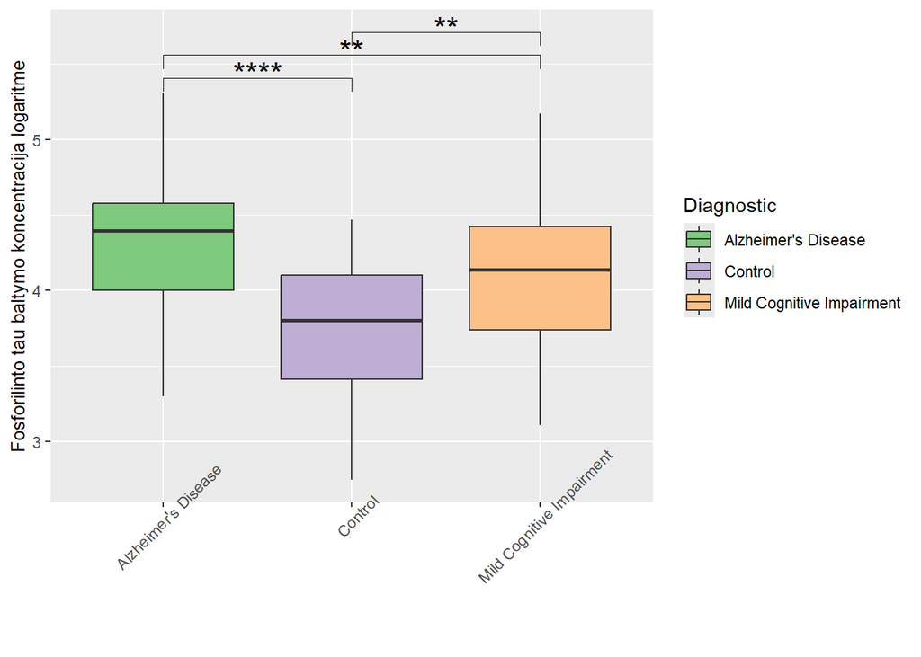

```r
pwc_Ptau <- pwc_Ptau |>  add_xy_position(x = "Diagnostic")

final_Ptau <- ggplot(alzaimeris_transformed, aes(Diagnostic, log_Ptau)) +
  geom_boxplot(aes(fill = Diagnostic)) +
  stat_pvalue_manual(pwc_Ptau, hide.ns = TRUE, size = 6) +
  scale_fill_brewer(palette = "Accent")  +
  labs(y = "Fosforilinto tau baltymo koncentracija logaritme") +
  theme(axis.title.x = element_blank(),
     axis.title.y = element_text(size = 10),
    axis.text.x = element_text(angle = 45)
    )

final_Ptau
```

Apibendrinu sudėdamas visus grafikus šalia kito

```r
isvadai <- (final_MMSE | final_amyloid | final_tau | final_Ptau) +
  plot_layout(guides = 'collect') +
  plot_annotation(tag_levels = 'A')
```

# Išvada

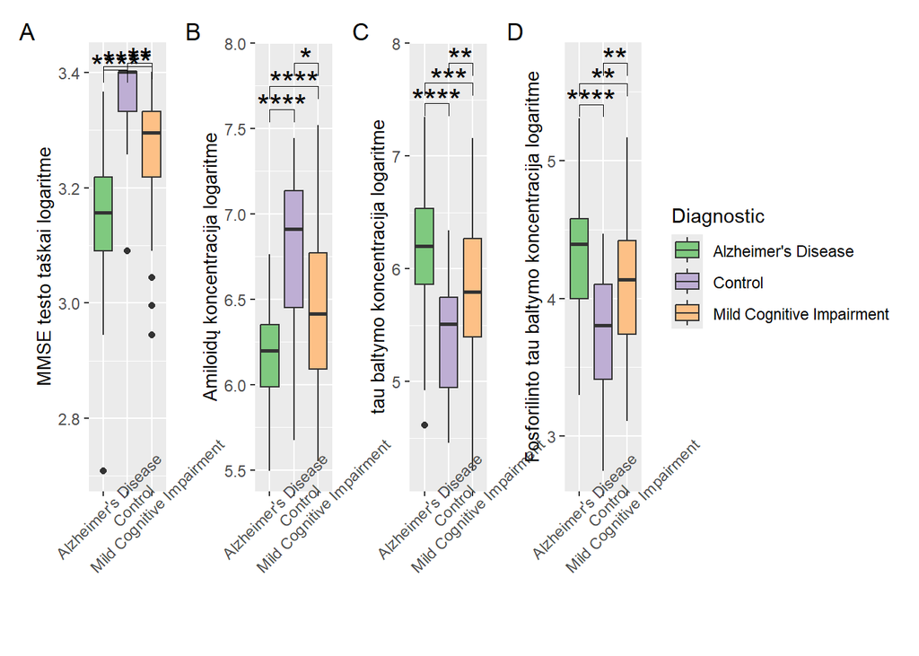

```r
isvadai
```

MMSE testo rezultatų (A) ir amiloidų (B) tau baltymo (C) ir fosforilinto tau baltymo (D) koncentracijos palyginimas cerebrospinalinio skysčio mėginiuose skirtingą protinį pajėgumą turinčiose žmonių grupėse. Statistiškai reikšmingi skirtumai pažymėti: * p < 0.05, ** p < 0.01, *** p < 0.001, **** p < 0.0001

Išsaugomi grafikai prezentacijai:

```r
ggsave("MMSE.png", plot = final_MMSE)
ggsave("amyloid.png", plot = final_amyloid)
ggsave("tau.png", plot = final_tau)
ggsave("Ptau.png", plot = final_Ptau)
ggsave("netrans.png", plot = netransformuotas)
ggsave("trans.png", plot = transformuotas)
```